# Modelado 3 meses

## Modelo naive

### Sampling

Hemos pasado el sampling a otra libreta de preparación de datos. De esta forma intentamos que el sampling sea el mismo para todos los modelos, evitando así posible overfitting.

### Modelado

#### Fórmula

En primer lugar, creamos la fórmula que vamos a usar.

```r
programados <- c("Camaras.factor","Frecuencia.min","R")
temporales <- c("Tiempo.desde.implante", "Voltaje.bateria",
"STIMA.fix","STIMVD.fix","STIMVI.fix","Choque.fix","ATP.fix","Episodios.factor")
y <- "x3M.fix"
x <- c(programados,
temporales)
fmla <- paste(y, paste(x, collapse="+"), sep="~")
print(fmla)
```

```
[1] "x3M.fix~Camaras.factor+Frecuencia.min+R+Tiempo.desde.implante+Voltaje.bateria+STIMA.fix+STIMVD.fix+STIMVI.fix+Choque.fix+ATP.fix+Episodios.factor"
```

#### Modelado

En segundo lugar, la aplicamos al modelo.

```r
model <- glm(fmla, data=trainingSet, family=binomial(link="logit"))
```

```
glm.fit: fitted probabilities numerically 0 or 1 occurred
```

```r
model
```

```
Call:  glm(formula = fmla, family = binomial(link = "logit"), data = trainingSet)

Coefficients:
          (Intercept)        Camaras.factor2        Camaras.factor3         Frecuencia.min
           -1.111e+02             -1.185e+01              4.079e+01              1.370e-01
                  RSi  Tiempo.desde.implante        Voltaje.bateria              STIMA.fix
            1.758e+01              9.413e-04              2.356e+01              2.083e-02
           STIMVD.fix             STIMVI.fix             Choque.fix                ATP.fix
           -3.584e-03             -7.713e-01              4.878e-01              3.476e-01
 Episodios.factorTRUE
            2.150e+01

Degrees of Freedom: 162 Total (i.e. Null);  150 Residual
  (5 observations deleted due to missingness)
Null Deviance:      51.4
Residual Deviance: 10.34    AIC: 36.34
```

#### Entrenamiento

Entrenamos con los datos.

```r
trainingSet$pred <- predict(model, newdata=trainingSet, type="response")
testSet$pred <- predict(model, newdata=testSet, type="response")
```

Y miramos los resultados.

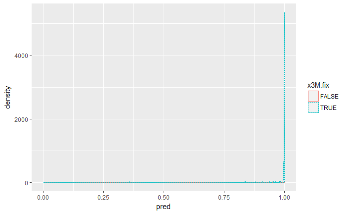

```r
library(ggplot2)
ggplot(trainingSet, aes(x=pred, color=x3M.fix, linetype=x3M.fix)) +
geom_density()
```

#### Precisión y recall

```r
library(ggplot2)
library(ROCR)
```

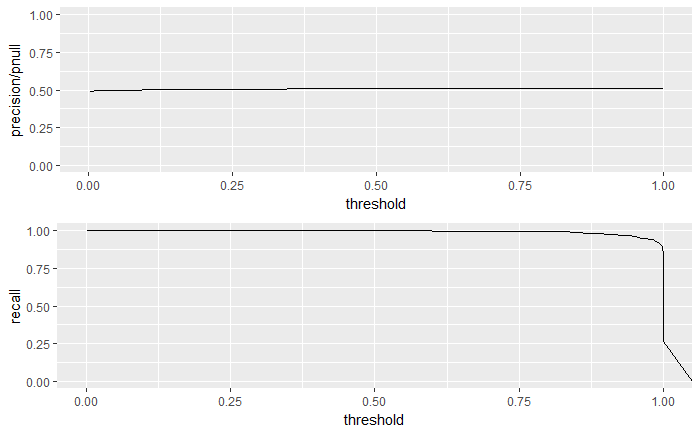

```r
library(grid)
predObj <- prediction(trainingSet$pred, trainingSet$x3M.fix)
precObj <- performance(predObj, measure="prec")
recObj <- performance(predObj, measure="rec")
precision <- (precObj@y.values)[[1]]
prec.x <- (precObj@x.values)[[1]]
recall <- (recObj@y.values)[[1]]
rocFrame <- data.frame(threshold=prec.x, precision=precision,
recall=recall)
nplot <- function(plist) {
n <- length(plist)
grid.newpage()
pushViewport(viewport(layout=grid.layout(n,1)))
vplayout=function(x,y) {viewport(layout.pos.row=x, layout.pos.col=y)}
for(i in 1:n) {
print(plist[[i]], vp=vplayout(i,1))
}
}
pnull <-
mean(as.numeric(trainingSet$x3M.fix))
p1 <- ggplot(rocFrame, aes(x=threshold)) +
geom_line(aes(y=precision/pnull)) +
coord_cartesian(xlim = c(0,1), ylim=c(0,1) )
p2 <- ggplot(rocFrame, aes(x=threshold)) +
geom_line(aes(y=recall)) +
coord_cartesian(xlim = c(0,1) )
nplot(list(p1, p2))
```

### EValuación

Para poder evaluar tenemos que elegir un treshold. Escogeremos en ambos un treshold de 0.60 para hacer las pruebas.

#### Tabla de verdad

Tabla de verdad

```r
ctab.test <- table(pred=testSet$pred>0.60, x3M.fix=testSet$x3M.fix)
ctab.test
```

```
       x3M.fix
pred    FALSE TRUE
  FALSE     9    4
  TRUE      5  330
```

#### Precisión

Precisión.

```r
precision <- ctab.test[2,2]/sum(ctab.test[2,])
precision
```

```
[1] 0.9850746
```

La precisión es bastante alta.

#### Recall

Recall.

```r
recall <- ctab.test[2,2]/sum(ctab.test[,2])
recall
```

```
[1] 0.988024
```

El recall también es bastante alto.

#### Enrich

Enrich

```r
enrich <- precision/mean(as.numeric(testSet$x3M.fix))
enrich
```

```
[1] 0.5024163
```

Lo identifica a una tasa de 0.5 veces mayor que el overall range? Qué significa eso?

#### Coeficientes

```r
coefficients(model)
```

```
          (Intercept)       Camaras.factor2       Camaras.factor3        Frecuencia.min
        -1.111276e+02         -1.185066e+01          4.079112e+01          1.369844e-01
                  RSi Tiempo.desde.implante       Voltaje.bateria             STIMA.fix
         1.758072e+01          9.413353e-04          2.355887e+01          2.082560e-02
           STIMVD.fix            STIMVI.fix            Choque.fix               ATP.fix
        -3.584212e-03         -7.712983e-01          4.877677e-01          3.476500e-01
 Episodios.factorTRUE
         2.149699e+01
```

#### Análisis del modelo

```r
summary(model)
```

```
Call:
glm(formula = fmla, family = binomial(link = "logit"), data = trainingSet)

Deviance Residuals:
     Min        1Q    Median        3Q       Max
-2.30915   0.00000   0.00006   0.01930   1.42785

Coefficients:
                        Estimate Std. Error z value Pr(>|z|)
(Intercept)           -1.111e+02  7.014e+03  -0.016   0.9874
Camaras.factor2       -1.185e+01  7.013e+03  -0.002   0.9987
Camaras.factor3        4.079e+01  8.440e+03   0.005   0.9961
Frecuencia.min         1.370e-01  7.389e-01   0.185   0.8529
RSi                    1.758e+01  4.694e+03   0.004   0.9970
Tiempo.desde.implante  9.413e-04  3.709e-03   0.254   0.7996
Voltaje.bateria        2.356e+01  9.979e+00   2.361   0.0182 *
STIMA.fix              2.083e-02  7.886e-02   0.264   0.7917
STIMVD.fix            -3.584e-03  3.199e-01  -0.011   0.9911
STIMVI.fix            -7.713e-01  1.070e+00  -0.721   0.4712
Choque.fix             4.878e-01  9.849e-01   0.495   0.6204
ATP.fix                3.477e-01  7.768e+00   0.045   0.9643
Episodios.factorTRUE   2.150e+01  2.337e+04   0.001   0.9993
---
Signif. codes:  0 *** 0.001 ** 0.01 * 0.05 . 0.1   1

(Dispersion parameter for binomial family taken to be 1)

    Null deviance: 51.400  on 162  degrees of freedom
Residual deviance: 10.336  on 150  degrees of freedom
  (5 observations deleted due to missingness)
AIC: 36.336

Number of Fisher Scoring iterations: 21
```

## Modelado tras el análisis

#### Fórmula

```r
programados <- c("Tiempo.desde.implante")
temporales <- c("Voltaje.bateria")
y <- "x3M.fix"
x <- c(programados,
temporales)
fmla <- paste(y, paste(x, collapse="+"), sep="~")
print(fmla)
```

```
[1] "x3M.fix~Tiempo.desde.implante+Voltaje.bateria"
```

#### Modelado

En segundo lugar, la aplicamos al modelo.

```r
model <- glm(fmla, data=trainingSet, family=binomial(link="logit"))
model
```

```
Call:  glm(formula = fmla, family = binomial(link = "logit"), data = trainingSet)

Coefficients:
          (Intercept)  Tiempo.desde.implante        Voltaje.bateria
           -77.055418               0.002173              15.026272

Degrees of Freedom: 167 Total (i.e. Null);  165 Residual
Null Deviance:      58.2
Residual Deviance: 25.16    AIC: 31.16
```

```r
trainingSet$pred <- predict(model, newdata=trainingSet, type="response")
testSet$pred <- predict(model, newdata=testSet, type="response")
```

Y miramos los resultados.

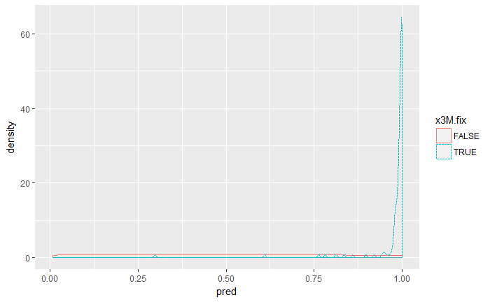

```r
library(ggplot2)
ggplot(trainingSet, aes(x=pred, color=x3M.fix, linetype=x3M.fix)) +
geom_density()
```

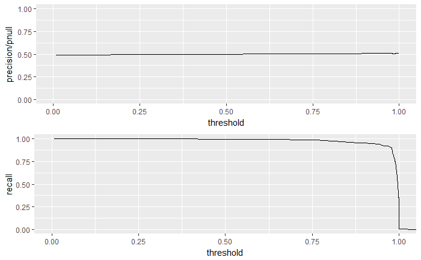

```r
library(grid)
predObj <- prediction(trainingSet$pred, trainingSet$x3M.fix)
precObj <- performance(predObj, measure="prec")
recObj <- performance(predObj, measure="rec")
precision <- (precObj@y.values)[[1]]
prec.x <- (precObj@x.values)[[1]]
recall <- (recObj@y.values)[[1]]
rocFrame <- data.frame(threshold=prec.x, precision=precision,
recall=recall)
nplot <- function(plist) {
n <- length(plist)
grid.newpage()
pushViewport(viewport(layout=grid.layout(n,1)))
vplayout=function(x,y) {viewport(layout.pos.row=x, layout.pos.col=y)}
for(i in 1:n) {
print(plist[[i]], vp=vplayout(i,1))
}
}
pnull <-
mean(as.numeric(trainingSet$x3M.fix))
p1 <- ggplot(rocFrame, aes(x=threshold)) +
geom_line(aes(y=precision/pnull)) +
coord_cartesian(xlim = c(0,1), ylim=c(0,1) )
p2 <- ggplot(rocFrame, aes(x=threshold)) +
geom_line(aes(y=recall)) +
coord_cartesian(xlim = c(0,1) )
nplot(list(p1, p2))
```

## EValuación

Para poder evaluar tenemos que elegir un treshold. Escogeremos en ambos un treshold de 0.60 para hacer las pruebas.

Tabla de verdad

```r
ctab.test <- table(pred=testSet$pred>0.60, x3M.fix=testSet$x3M.fix)
ctab.test
```

```
       x3M.fix
pred    FALSE TRUE
  FALSE    14    7
  TRUE      0  335
```

Precisión.

```r
precision <- ctab.test[2,2]/sum(ctab.test[2,])
precision
```

```
[1] 1
```

La precisión es bastante alta.

Recall.

```r
recall <- ctab.test[2,2]/sum(ctab.test[,2])
recall
```

```
[1] 0.9795322
```

Enrich

```r
enrich <- precision/mean(as.numeric(testSet$x3M.fix))
enrich
```

```
[1] 0.5100287
```

Lo identifica a una tasa de 0.5 veces mayor que el overall range? Qué significa eso?

## Evaluando el modelo

```r
coefficients(model)
```

```
          (Intercept) Tiempo.desde.implante       Voltaje.bateria
        -77.055417534           0.002173118          15.026272072
```

```r
summary(model)
```

```
Call:
glm(formula = fmla, family = binomial(link = "logit"), data = trainingSet)

Deviance Residuals:
     Min        1Q    Median        3Q       Max
-2.97270   0.00122   0.08983   0.14822   1.55414

Coefficients:
                        Estimate Std. Error z value Pr(>|z|)
(Intercept)           -77.055418  23.166737  -3.326 0.000881 ***
Tiempo.desde.implante   0.002173   0.001268   1.713 0.086645 .
Voltaje.bateria        15.026272   4.291442   3.501 0.000463 ***
---
Signif. codes:  0 *** 0.001 ** 0.01 * 0.05 . 0.1   1

(Dispersion parameter for binomial family taken to be 1)

    Null deviance: 58.197  on 167  degrees of freedom
Residual deviance: 25.163  on 165  degrees of freedom
AIC: 31.163

Number of Fisher Scoring iterations: 9
```

## Modelado solo con el voltaje de la batería

#### Fórmula

```r
temporales <- c("Voltaje.bateria")
y <- "x3M.fix"
x <- c(temporales)
fmla <- paste(y, paste(x, collapse="+"), sep="~")
print(fmla)
```

```
[1] "x3M.fix~Voltaje.bateria"
```

#### Modelado

```r
model <- glm(fmla, data=trainingSet, family=binomial(link="logit"))
model
```

```
Call:  glm(formula = fmla, family = binomial(link = "logit"), data = trainingSet)

Coefficients:
    (Intercept)  Voltaje.bateria
         -53.56            11.24

Degrees of Freedom: 167 Total (i.e. Null);  166 Residual
Null Deviance:      58.2
Residual Deviance: 28.26    AIC: 32.26
```

```r
trainingSet$pred <- predict(model, newdata=trainingSet, type="response")
testSet$pred <- predict(model, newdata=testSet, type="response")
```

#### Resultados

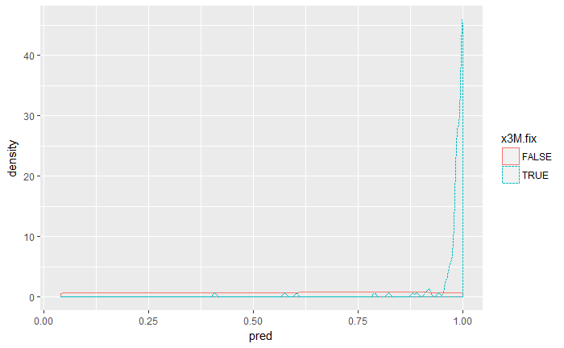

```r
library(ggplot2)
ggplot(trainingSet, aes(x=pred, color=x3M.fix, linetype=x3M.fix)) +
geom_density()
```

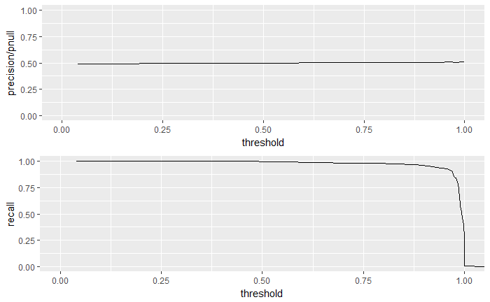

```r
library(grid)
predObj <- prediction(trainingSet$pred, trainingSet$x3M.fix)
precObj <- performance(predObj, measure="prec")
recObj <- performance(predObj, measure="rec")
precision <- (precObj@y.values)[[1]]
prec.x <- (precObj@x.values)[[1]]
recall <- (recObj@y.values)[[1]]
rocFrame <- data.frame(threshold=prec.x, precision=precision,
recall=recall)
nplot <- function(plist) {
n <- length(plist)
grid.newpage()
pushViewport(viewport(layout=grid.layout(n,1)))
vplayout=function(x,y) {viewport(layout.pos.row=x, layout.pos.col=y)}
for(i in 1:n) {
print(plist[[i]], vp=vplayout(i,1))
}
}
pnull <-
mean(as.numeric(trainingSet$x3M.fix))
p1 <- ggplot(rocFrame, aes(x=threshold)) +
geom_line(aes(y=precision/pnull)) +
coord_cartesian(xlim = c(0,1), ylim=c(0,1) )
p2 <- ggplot(rocFrame, aes(x=threshold)) +
geom_line(aes(y=recall)) +
coord_cartesian(xlim = c(0,1) )
nplot(list(p1, p2))
```

## EValuación

```r
ctab.test <- table(pred=testSet$pred>0.70, x3M.fix=testSet$x3M.fix)
ctab.test
```

```
       x3M.fix
pred    FALSE TRUE
  FALSE    14   10
  TRUE      0  332
```

#### Precisión

```r
precision <- ctab.test[2,2]/sum(ctab.test[2,])
precision
```

```
[1] 1
```

#### Recall

```r
recall <- ctab.test[2,2]/sum(ctab.test[,2])
recall
```

```
[1] 0.9707602
```

#### Enrich

```r
enrich <- precision/mean(as.numeric(testSet$x3M.fix))
enrich
```

```
[1] 0.5100287
```

## Evaluando el modelo

#### Coeficientes

```r
coefficients(model)
```

```
    (Intercept) Voltaje.bateria
      -53.55503        11.24426
```

#### Modelo

```r
summary(model)
```

```
Call:
glm(formula = fmla, family = binomial(link = "logit"), data = trainingSet)

Deviance Residuals:
     Min        1Q    Median        3Q       Max
-2.91711   0.00233   0.11760   0.17153   1.33789

Coefficients:
                Estimate Std. Error z value Pr(>|z|)
(Intercept)      -53.555     14.976  -3.576 0.000349 ***
Voltaje.bateria   11.244      3.033   3.707 0.000210 ***
---
Signif. codes:  0 *** 0.001 ** 0.01 * 0.05 . 0.1   1

(Dispersion parameter for binomial family taken to be 1)

    Null deviance: 58.197  on 167  degrees of freedom
Residual deviance: 28.265  on 166  degrees of freedom
AIC: 32.265

Number of Fisher Scoring iterations: 8
```

Probamos a predecir algunos valores

```r
newdata = data.frame(Voltaje.bateria = 6.0, Tiempo.desde.implante = 1000)
predict(model, newdata, type="response")
```

```
        1
0.9999991
```